# k-nearest neighbors algorithm

Przemyslaw Biecek

Data Mining - Advances

# Introduction

In this part we are going to cover following topics:

- basics of k-nearest neighbors algorithm
- how to create knn classifier in R
- how to choose the k parameter in knn classifier

We are going to work with two datasets: `pancan` and `iris`. See the `Introduction` for more details.

# Overview of the k-nearest neighbors method

The k-nearest neighbors algorithm is a distance based method. The default distance is the Euclidian one, but choose the metric wisely.

Let’s start with an example based on two variables / two dimensions. The example below is based on the `pancan` data.

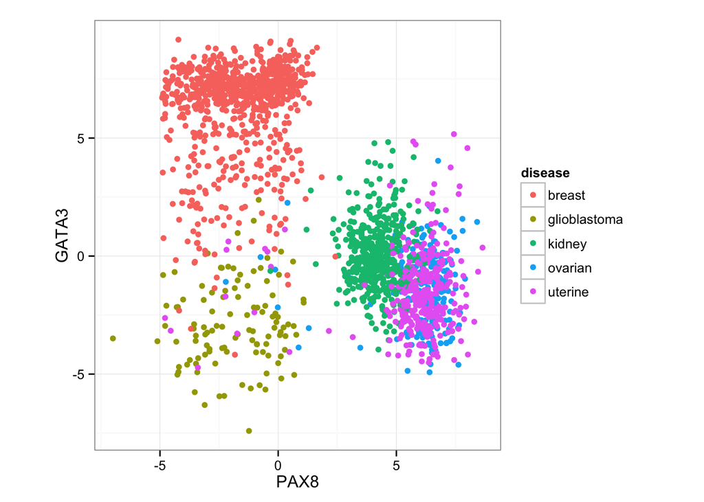

```r
library(ggplot2)
load("pancan.rda")
# change levels for nicer presentation
levels(pancan$disease) <- c("breast", "glioblastoma", "kidney", "ovarian", "uterine")

ggplot(pancan, aes(PAX8, GATA3, color=disease)) +
  geom_point() +
  theme_bw() + coord_fixed()
```

The kNN algorithm works in three steps:

- For a new sample a set of k-nearest samples from the training dataset is identified. Let’s denote this set as NN.
- For samples in the set NN the distribution of classes is calculated.
- For the new sample the final class is established by majority voting. Each sample in NN votes for it’s class.

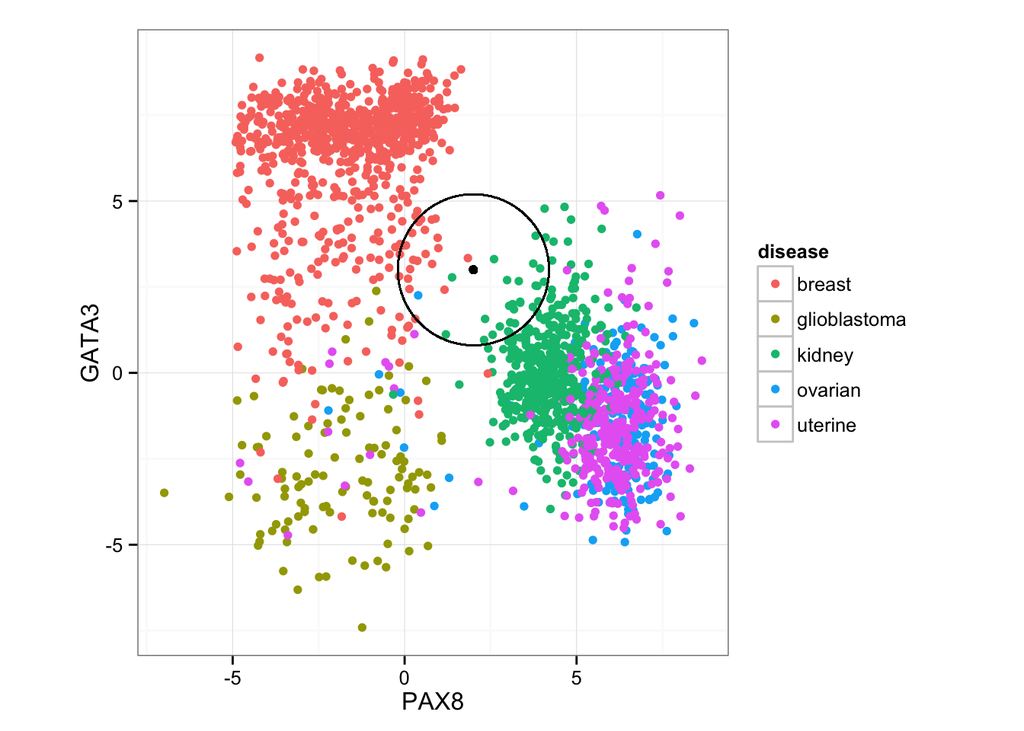

```r
ggplot(pancan, aes(PAX8, GATA3, color=disease)) +
  geom_point() +
  theme_bw() + coord_fixed() +
  geom_point(x=2, y=3, size=35, color="black", shape=1) +
  geom_point(x=2, y=3, size=2, color="black")
```

# How to train and use kNN in R

Let’s train this classifier with R. The kNN method is implemented in a few different packages. Here we are going to use `knn3()` from `caret`.

```r
library(caret)
knnFit <- knn3(disease ~ PAX8+GATA3, data = pancan, k=20, prob=TRUE)
knnFit
```

```
## 20-nearest neighbor classification model
## Training set class distribution:
##
##       breast glioblastoma       kidney      ovarian      uterine
##          806          110          454          218          356
```

The trained classifier is in the `knnFit` object. Use the `predict()` function in order to apply it to a new data set. By default it returns distribution of votes for each sample. Use `type="class"` to predict the class of new samples.

```r
pred <- predict(knnFit, data.frame(PAX8 = 2, GATA3= 3))
t(pred)
```

```
##              [,1]
## breast       0.40
## glioblastoma 0.00
## kidney       0.55
## ovarian      0.05
## uterine      0.00
```

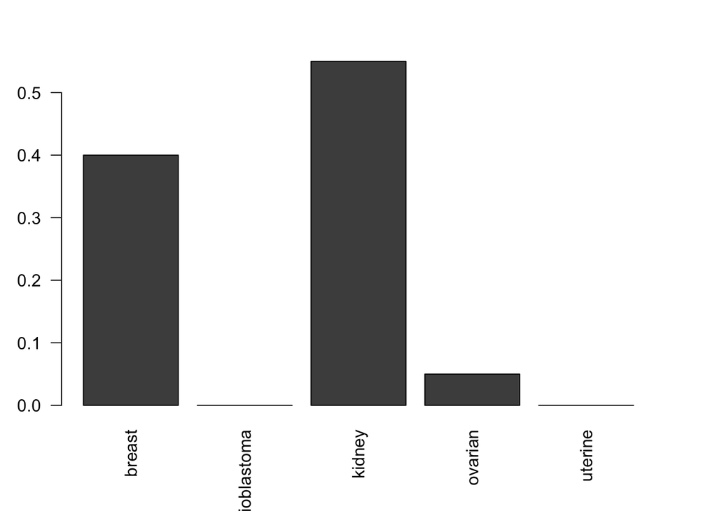

```r
par(mar=c(5,3,3,3))
barplot(pred, las=2)
```

```r
# majority voting
predict(knnFit, data.frame(PAX8 = 2, GATA3= 3), type="class")
```

```
## [1] kidney
## Levels: breast glioblastoma kidney ovarian uterine
```

# Quality of the classifier

How to asses how good is the trained classifier?

Let’s start with a contingency table for the predicted labels crossed with true labels.

```r
knnFit <- knn3(disease ~ PAX8+GATA3, data = pancan, k=1)
pred <- predict(knnFit, pancan, type="class")

tab <- table(true = pancan$disease, predicted = pred)
tab
```

```
##               predicted
## true           breast glioblastoma kidney ovarian uterine
##   breast          806            0      0       0       0
##   glioblastoma      0          110      0       0       0
##   kidney            0            0    454       0       0
##   ovarian           0            0      0     218       0
##   uterine           0            0      0       0     356
```

```r
sum(diag(tab)) / sum(tab)
```

```
## [1] 1
```

## Over fitting

It looks like the performance is 100%. Is it possible? Maybe, but here it is a result of over fitting.

Note: One should not calculate performance of a classifier on the same dataset that have been used for training. Never!

What else can we do?

## Testing and Training

Let’s divide the dataset into two subsets: training and testing.

```r
indxTrain <- createDataPartition(y = pancan$disease, p = 0.75)
str(indxTrain)
```

```
## List of 1
##  $ Resample1: int [1:1460] 1 2 3 6 8 9 14 15 16 18 ...
```

```r
pancanTrain <- pancan[indxTrain$Resample1,]
pancanTest <- pancan[-indxTrain$Resample1,]
```

Now we can train classifier on the training dataset and test it on the second dataset.

```r
knnFit <- knn3(disease ~ PAX8+GATA3, data = pancanTrain, k=1)
pred <- predict(knnFit, pancanTest, type="class")

tab <- table(true = pancanTest$disease, predicted = pred)
tab
```

```
##               predicted
## true           breast glioblastoma kidney ovarian uterine
##   breast          196            3      2       0       0
##   glioblastoma      1           23      0       1       2
##   kidney            0            0     95       6      12
##   ovarian           2            1      4      18      29
##   uterine           0            2     14      27      46
```

```r
sum(diag(tab)) / sum(tab)
```

```
## [1] 0.7809917
```

# How to choose k?

The performance may be assessed for different values of parameter k. Based on such results one can select the ,,optimal’’ k, i.e. k that maximizes some measure of performance. Here the performance is just the fraction of correct guesses (called accuracy). We will introduce more measures for performance later.

```
## geom_smooth: method="auto" and size of largest group is <1000, so using loess. Use 'method = x' to change the smoothing method.
```

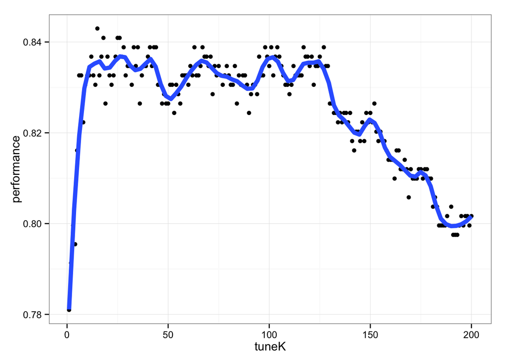

```r
tuneK <- 1:200
performance <- sapply(tuneK, function(k) {
  knnFit <- knn3(disease ~ PAX8+GATA3, data = pancanTrain, k=k)
  tab <- table(true = pancanTest$disease,
          predict = predict(knnFit, pancanTest, type="class"))
  sum(diag(tab)) / sum(tab)
})

df <- data.frame(tuneK, performance)

ggplot(df, aes(tuneK, performance)) +
  geom_point() +
  geom_smooth(se=FALSE, span=0.1, size=2) +
  theme_bw()
```

# Other issues

Note that by default the Euclidian distance is used. To make sure that all variables have the same impact on results one should first normalize each variable that is used for predictions. It is not obligatory, but it is a good practice if different variables are measured in different units.

Note that majority voting is not best solution if classes have unequal distribution. If one class is predominant then it may happen that the classifier will vote for it in every case. In order to deal with unbalanced labels one can consider weighted votes.

# Computer classes

1. Train the kNN classifier for the `iris` dataset.
2. Calculate the performance for this classifier.
3. Normalize all predictive variables (Length’s and Width’s).
4. Calculate the performance for classifier build over normalized variables (compare with point 2).

# Home work

Use `knitr` to create a report for kNN method based on `GermanCredit` dataset.

Choose 5 variables and build classifier for them. The response variable is the ‘Class’.

Find optimal `k` and calculate performance for it.

# Additional materials

A Short Introduction to the `caret` Package

https://cran.r-project.org/web/packages/caret/vignettes/caret.pdf